# UseR! 2019 Spatial workshop part I

Edzer Pebesma

2019-07-08

## Part I (90’)

- A. Spatial data, simple features (20’ + 10’ exercises)
- B. Temporal data, raster data (20’ + 10’ exercises)
- C. Raster/vector data cubes, large rasters (20’ + 10’ exercises)

## A. Spatial data and simple features

Since data collections can only be done *somewhere*, and at *some time*, all data is, in principle spatial and temporal. In many cases location are implicit, and for instance encoded as ID of an object. In other cases, locations are encoded with *coordinates*.

Coordinates can be three-dimensional $(x, y, z)$, but are in many cases two-dimensional $(x, y)$. For *geo* spatial data, that is, data that are Earth-bound, two-dimensional coordinates are either

- [geographic](https://en.wikipedia.org/wiki/Geographic_coordinate_system): angles (degrees longitude and latitude), pointing out locations on an ellipsoid or sphere
- projected: measured in a two-dimensional flat space, e.g. in metres, related to an ellipsoid by [*projection*](https://en.wikipedia.org/wiki/Map_projection)

A **coordinate reference sytem** (CRS) describes how coordinates are to be interpreted: which location on Earth do they refer to. In case of projected coordinates the CRS contains the projection type and parameters, in all cases which reference ellipsoid the original geographic coordinates are associated with (e.g., WGS84, or NAD27).

### Objects and fields, features

It makes in many cases sense to distinguish to “types” of spatial information, depending on whether variation is discrete or continuous *over space*:

- **objects** are discrete things: houses, cars, rivers, persons, which have a location and other properties
- **fields** are continuous phenomena: temperature and pressure of air, elevation of the Earth surface; fields are essentially *functions* mapping from two- or three-dimensional space (and possibly time) to a value.

[OGC](https://www.opengeospatial.org/), a standardisation body for geospatial information, defines in its [abstract specification](http://www.opengeospatial.org/docs/as) a [feature](https://www.opengeospatial.org/standards/sfa) as an “abstraction of real world phenomena” that has a geometry and attributes (other characteristics). Abstractions of both objects and fields are considered **features**.

**Simple features** are features with all geometric attributes described piecewise by straight line or planar interpolation between sets of points (Herring 2011); simple feature geometries are of type

- `point`, `multipoint`,
- `linestring`, `multilinestring`,
- `polygon`, `multipolygon`, or
- combinations of these (`geometrycollection`).

**Coverages** is the term OGC uses to represent field variables; the are typically (but not necessarily) associated with raster data.

### Support

In the following figure:

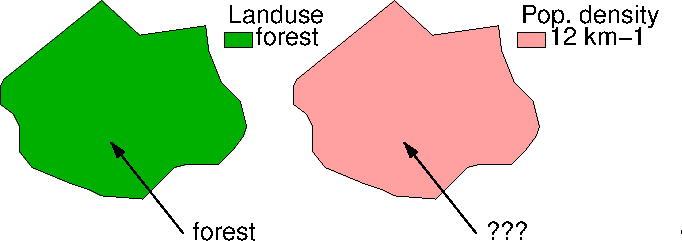

what is the value at the point location pointed to with the arrow?

- For *land use*, we have an infinite set of point observations; for every point in the polygon we know the land use; although this would maybe be only one *record* in our tables, this is a field variable (or “coverage”) representing a large set of points.
- for *population density* we have a single observation, which is an aggregation for the entire polygon (the sum of the inhabitants, divided by the polygon area). This is a feature attribute.

**Support** is the physical size (length, area, volume) a single quantity, or measurement, is associated with. For the land use variable, we have *point support*. For the population density variable we have support the *size of the area aggreated over*.

### intro to `sf`

`sf` uses the OSGEO stack of software:

```r
library(tidyverse) # although not needed for working with sf!
library(sf)
```

Package `sf` provides handling of feature data, where feature geometries are points, lines, polygons or combinations of those. It implements the full set of geometric functions described in the *simple feature access* standard, and some. The basic storage is very simple, and uses only base R types (list, matrix).

- feature sets are held as records (rows) in `sf` objects, inheriting from `data.frame` or `tbl_df`
- `sf` objects have at least one simple feature geometry list-column of class `sfc`
- `sfc` geometry list-columns have a bounding box and a coordinate reference system as attribute, and a class attribute pointing out the common type (or `GEOMETRY` in case of a mix)
- a single simple feature geometry is of class `sfg`, and further classes pointing out dimension and type

Storage of simple feature geometry:

- `POINT` is a numeric vector
- `LINESTRING` and `MULTIPOINT` are numeric matrix, points/vertices in rows
- `POLYGON` and `MULTILINESTRING` are lists of matrices
- `MULTIPOLYGON` is a lists of those
- `GEOMETRYCOLLECTION` is a list of typed geometries

To build from scratch:

```r
p1 = st_point(c(3,5))
class(p1)
```

```
## [1] "XY"    "POINT" "sfg"
```

```r
p2 = st_point(c(4,6))
p3 = st_point(c(4,4))
pts = st_sfc(p1, p2, p3)
class(pts)
```

```
## [1] "sfc_POINT" "sfc"
```

```r
sf = st_sf(a = c(3,2.5,4), b = c(1,2,4), geom = pts)
class(sf)
```

```
## [1] "sf"         "data.frame"
```

```r
sf = st_as_sf(tibble::tibble(a = c(3,2.5,4), b = c(1,2,4), geom = pts))
class(sf)
```

```
## [1] "sf"         "tbl_df"     "tbl"        "data.frame"
```

```r
sf
```

```
## Simple feature collection with 3 features and 2 fields
## geometry type:  POINT
## dimension:      XY
## bbox:           xmin: 3 ymin: 4 xmax: 4 ymax: 6
## epsg (SRID):    NA
## proj4string:    NA
## # A tibble: 3 x 3
##       a     b    geom
##   <dbl> <dbl> <POINT>
## 1   3       1   (3 5)
## 2   2.5     2   (4 6)
## 3   4       4   (4 4)
```

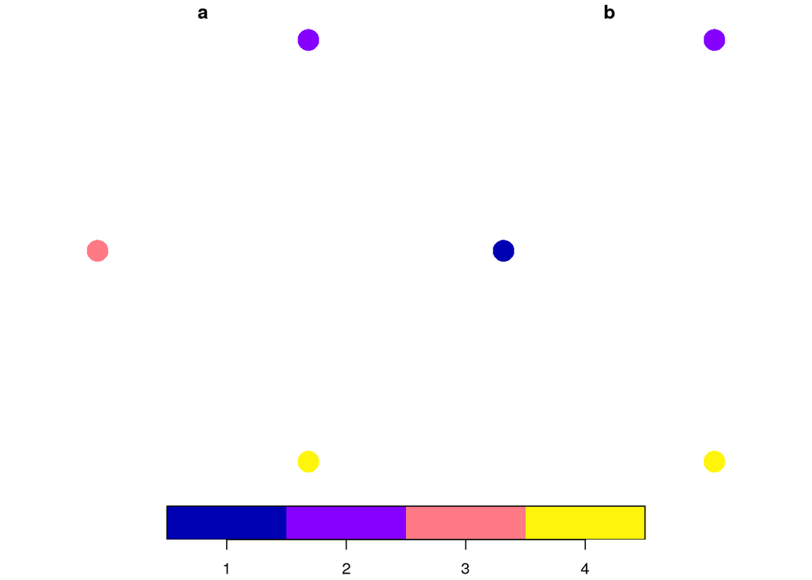

```r
plot(sf, cex = 3, pch = 16, key.pos = 1, breaks = seq(.5,4.5,1), pal = sf.colors(4))
```

We can read some real data:

```r
nc = read_sf(system.file("gpkg/nc.gpkg", package="sf")) # read as sf-tibble
agr = c(AREA = "aggregate", PERIMETER = "aggregate", CNTY_ = "identity",
  CNTY_ID = "identity", NAME = "identity", FIPS = "identity", FIPSNO = "identity",
  CRESS_ID = "identity", BIR74 = "aggregate", SID74 = "aggregate", NWBIR74 = "aggregate",
  BIR79 = "aggregate", SID79 = "aggregate", NWBIR79  = "aggregate")
st_agr(nc) = agr
nc[c(9:11,15)]
```

```
## Simple feature collection with 100 features and 3 fields
## Attribute-geometry relationship: 0 constant, 3 aggregate, 0 identity
## geometry type:  MULTIPOLYGON
## dimension:      XY
## bbox:           xmin: -84.32385 ymin: 33.88199 xmax: -75.45698 ymax: 36.58965
## epsg (SRID):    4267
## proj4string:    +proj=longlat +datum=NAD27 +no_defs
## # A tibble: 100 x 4
##    BIR74 SID74 NWBIR74                                                 geom
##    <dbl> <dbl>   <dbl>                                   <MULTIPOLYGON [°]>
##  1  1091     1      10 (((-81.47276 36.23436, -81.54084 36.27251, -81.5619…
##  2   487     0      10 (((-81.23989 36.36536, -81.24069 36.37942, -81.2628…
##  3  3188     5     208 (((-80.45634 36.24256, -80.47639 36.25473, -80.5368…
##  4   508     1     123 (((-76.00897 36.3196, -76.01735 36.33773, -76.03288…
##  5  1421     9    1066 (((-77.21767 36.24098, -77.23461 36.2146, -77.29861…
##  6  1452     7     954 (((-76.74506 36.23392, -76.98069 36.23024, -76.9947…
##  7   286     0     115 (((-76.00897 36.3196, -75.95718 36.19377, -75.98134…
##  8   420     0     254 (((-76.56251 36.34057, -76.60424 36.31498, -76.6482…
##  9   968     4     748 (((-78.30876 36.26004, -78.28293 36.29188, -78.3212…
## 10  1612     1     160 (((-80.02567 36.25023, -80.45301 36.25709, -80.4353…
## # … with 90 more rows
```

where `st_agr` specifies the *attribute geometry relationship*, indicating for each attribute whether we have polygon support (`aggregate`) or point support (`constant` or `identity`) for the attributes.

Suppose we want to query the `nc` dataset at `POINT (-78.25073 34.07663)` (so-called *well known text* encoding of points with these x and y coordinate), then we can do this by

```r
pt = st_as_sfc("POINT (-78.25073 34.07663)")
st_intersection(nc, st_sfc(pt, crs = st_crs(nc)))
```

```
## although coordinates are longitude/latitude, st_intersection assumes that they are planar
```

```
## Warning: attribute variables are assumed to be spatially constant
## throughout all geometries
```

```
## Simple feature collection with 1 feature and 14 fields
## geometry type:  POINT
## dimension:      XY
## bbox:           xmin: -78.25073 ymin: 34.07663 xmax: -78.25073 ymax: 34.07663
## epsg (SRID):    4267
## proj4string:    +proj=longlat +datum=NAD27 +no_defs
## # A tibble: 1 x 15
##    AREA PERIMETER CNTY_ CNTY_ID NAME  FIPS  FIPSNO CRESS_ID BIR74 SID74
##   <dbl>     <dbl> <dbl>   <dbl> <chr> <chr>  <dbl>    <int> <dbl> <dbl>
## 1 0.212      2.02  2241    2241 Brun… 37019  37019       10  2181     5
## # … with 5 more variables: NWBIR74 <dbl>, BIR79 <dbl>, SID79 <dbl>,
## #   NWBIR79 <dbl>, geom <POINT [°]>
```

This generates a warning because some of the variables have non-point support, meaning that probably a meaningless value is now attached to a point geometry. The warning is not emitted if the attribute variable returned has point support, as in

```r
i = st_intersection(nc["CNTY_"], st_sfc(pt, crs = st_crs(nc)))
```

```
## although coordinates are longitude/latitude, st_intersection assumes that they are planar
```

The remaining warning is justified, as we are doing 2D flat geometry on spherical (ellipsoidal), geographical coordinates. This is often works out, but not always. It goes away when we work with projected (planar) coordinates, e.g. in

```r
nc1 = st_transform(nc, 2264) # NC state plain, US feet
pt1 = st_transform(st_sfc(pt, crs = st_crs(nc)), 2264)
i1 = st_intersection(nc1["CNTY_"], pt1)
```

We can plot two variable, for instance using base plot

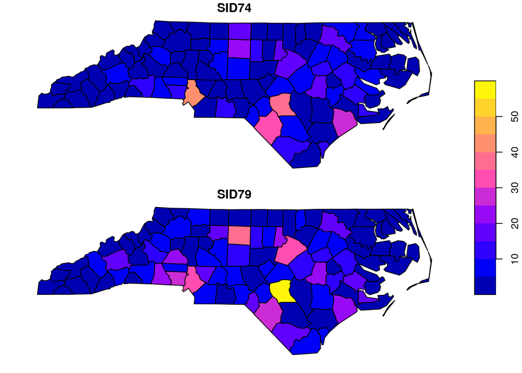

```r
plot(nc[c("SID74", "SID79")], key.pos = 4)
```

or `ggplot`:

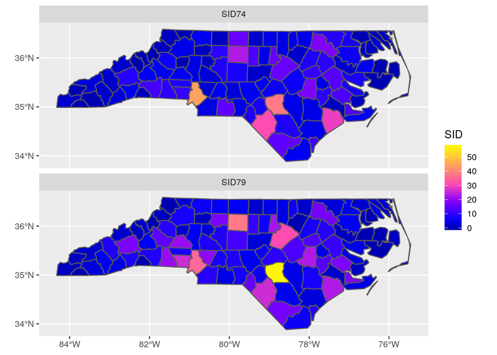

```r
nc %>% select(SID74, SID79) %>% gather(VAR, SID, -geom) -> nc2 # stack two columns
ggplot() + geom_sf(data = nc2, aes(fill = SID)) + facet_wrap(~VAR, ncol = 1) +
  scale_y_continuous(breaks = 34:36) +
  scale_fill_gradientn(colors = sf.colors(12))
```

### Exercises

1. start R, install package `sf` if not already present, and load it
2. load the `nc` sample dataset as done above
3. use `st_intersects` to discover which counties in `nc` intersect with county `Rowan`; experiment with the order of arguments to `st_intersects`
4. try to understand the object returned by `st_intersects`
5. look up which methods are available for objects of class `sgbp` (`methods(class = "sgbp")`), and try some of them
6. does `Rowan` intersect with itself?
7. Find all counties that touch `Rowan` by using `st_touches`; does `Rowan` touch itself?
8. How can we find what `intersects` and `touches` mean, more formally?

## B. Temporal data, raster data (20’ + 10’ exercises)

### Time in R

Base R has two time classes:

```r
(dt = Sys.Date())
```

```
## [1] "2019-07-08"
```

```r
class(dt)
```

```
## [1] "Date"
```

```r
(tm = Sys.time())
```

```
## [1] "2019-07-08 17:07:22 CEST"
```

```r
class(tm)
```

```
## [1] "POSIXct" "POSIXt"
```

where `Date` has (integer) numbers representing the day number, and `POSIXct` has (double, decimal) seconds, both counting since Jan 1, 1970, 00:00 UTC.

### Time series data

Packages `zoo` and `xts` provide classes for working with matrices of data, with a time index for each row. The more recent package `tsibble` does something similar, extending `tibbles` rather than `matrix`.

We will use a small piece of the `air` dataset in `spacetime`:

```r
data(air, package = "spacetime") # requires spacetime to be installed
sel = 1800:2300
library(xts)
a.xts = xts(t(air)[sel,], order.by = dates[sel])
```

```r
xts::.parseISO8601("2002-03")
```

```
## $first.time
## [1] "2002-03-01 CET"
##
## $last.time
## [1] "2002-03-31 23:59:59 CEST"
```

and they can be used for time selection; we can select the first six months of 2003 (rows) and the first four stations (columns), using

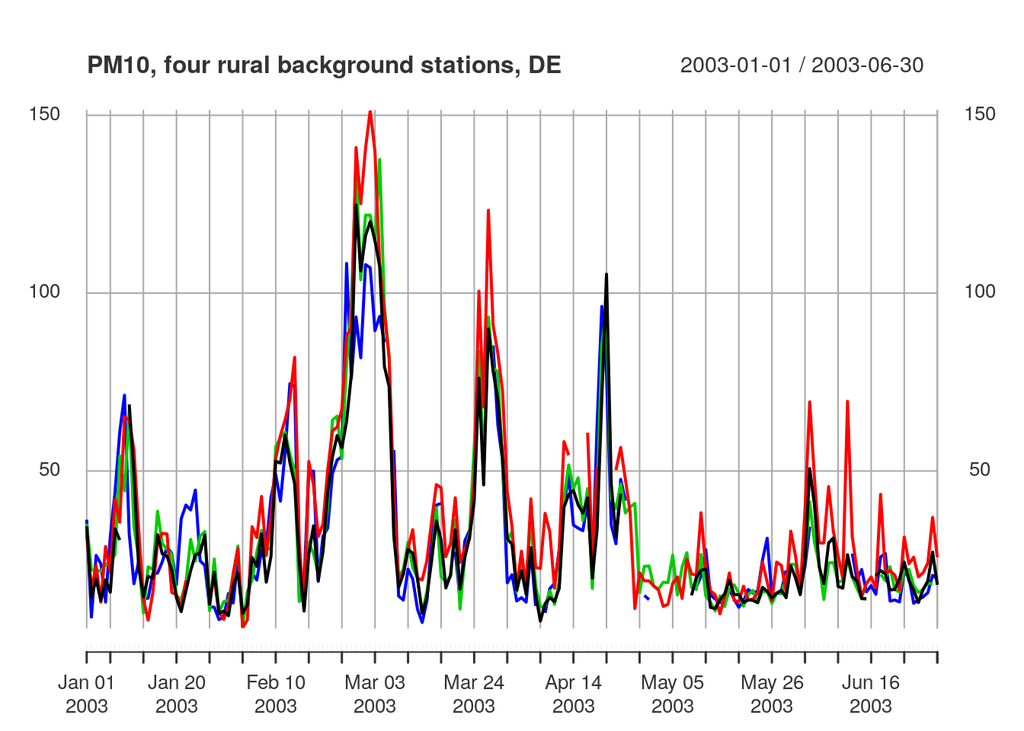

```r
plot(a.xts["2003-01/2003-06",1:4], main = "PM10, four rural background stations, DE")
```

Neither `xts`, nor (to my knowledge) other R packages for time series data, keep an explicit record of the time *periods* for which individual records are valid. The PM10 data examined here e.g. are daily averages, but a single time stamp (for daily data the start of the day, by convention) is registered for each observation.

The data considered here form a kind of a space-time raster, as shown by

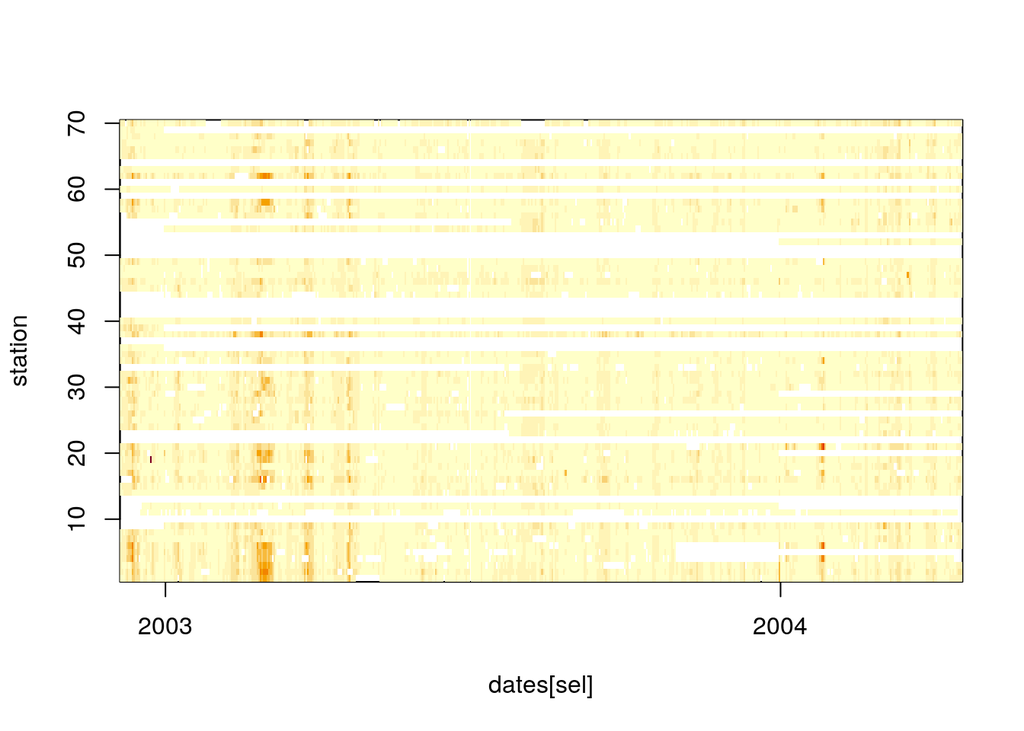

```r
image(dates[sel], 1:70, as.matrix(a.xts), ylab = "station")
```

### Raster data

Raster data represent a 2-D matrix, where dimensions (rows/cols) map uniquely into coordinates.

In the simplest case of a

- **regular raster**
  - $c(i) = o + (i-1) \times \delta, \ \ i = 1,2,...,n$
  - $o$ is the border or the raster, $\delta$ the cell size
  - for x, $\delta$ is usually positive, for y, negative (and $o$ the top edge)
  - index space is continuous: integer $i$ implies $[i,i+1)$
  - every coordinate value maps to a unique index (unlike polygon coverages, where boundaries are ambiguous)

More complex rasters are

- **rotated raster**
  - column and row dimensions are not alined with x and y axis
- **sheared raster**
  - column and row dimensions are no longer perpendicular
- **rectilinear raster**
  - increments along column and row dimension are not constant
- **curvilinear raster**
  - every col/row combination has its own x and y value (or corner values)

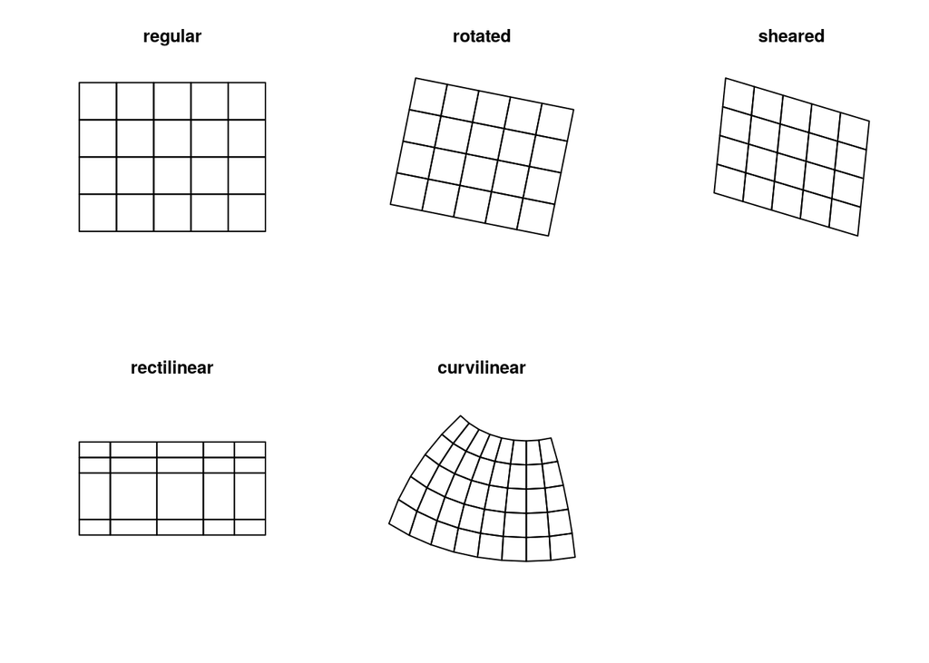

### Analysing raster data

Package [`raster`](https://rspatial.org/raster/index.html) has been around for a long time, is robust, well tested, versatile, and works for large rasters. We will not discuss it here.

The more recent [`stars`](https://r-spatial.github.io/stars/) package has a different take on raster data, and will be used here. The following example loads 6 bands from a (section of a) Landsat 7 image, and plots it:

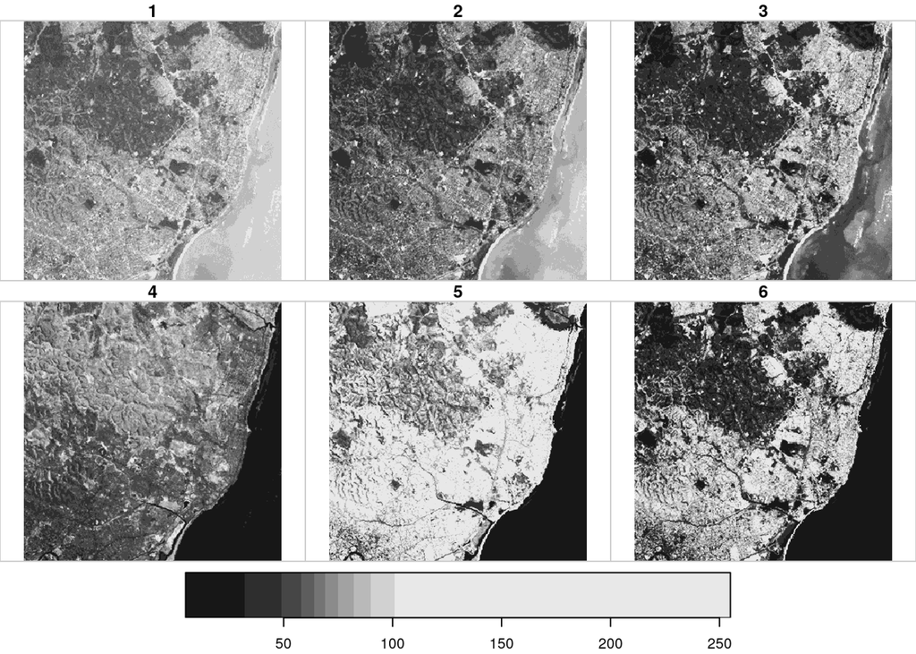

```r
library(stars) # will load sf
tif = system.file("tif/L7_ETMs.tif", package = "stars")
x = read_stars(tif)
plot(x)
```

The irregular color breaks come from the default of using “type = quantile” to `classInt::classIntervals()`, which causes [histogram stretching](https://en.wikipedia.org/wiki/Histogram_equalization); this is done over all 6 bands.

### stars: out-of-memory (if time permits)

Copernicus’ [Sentinel 2](https://en.wikipedia.org/wiki/Sentinel-2) provides the state-of-the art multispectral satellite images of today: 10 m resolution, 5 days intervals. A sample image is provided in the (off-CRAN) 1 Gb `starsdata` package:

```r
install.packages("starsdata", repos = "https://cran.uni-muenster.de/pebesma" , type = "source")
library(starsdata)
```

```r
have_starsdata = require("starsdata") # TRUE to do the big data example with pkg starsdata; instructions for installing below
```

We will read in the four 10-m resolution bands:

```r
granule = system.file("sentinel/S2A_MSIL1C_20180220T105051_N0206_R051_T32ULE_20180221T134037.zip", package = "starsdata")
base_name = strsplit(basename(granule), ".zip")[[1]]
s2 = paste0("SENTINEL2_L1C:/vsizip/", granule, "/", base_name, ".SAFE/MTD_MSIL1C.xml:10m:EPSG_32632")
(p = read_stars(s2, proxy = TRUE))
```

```
## stars_proxy object with 1 attribute in file:
## $`MTD_MSIL1C.xml:10m:EPSG_32632`
## [1] "SENTINEL2_L1C:/vsizip//home/edzer/R/x86_64-pc-linux-gnu-library/3.6/starsdata/sentinel/S2A_MSIL1C_20180220T105051_N0206_R051_T32ULE_20180221T134037.zip/S2A_MSIL1C_20180220T105051_N0206_R051_T32ULE_20180221T134037.SAFE/MTD_MSIL1C.xml:10m:EPSG_32632"
##
## dimension(s):
##      from    to offset delta                       refsys point values
## x       1 10980  3e+05    10 +proj=utm +zone=32 +datum...    NA   NULL [x]
## y       1 10980  6e+06   -10 +proj=utm +zone=32 +datum...    NA   NULL [y]
## band    1     4     NA    NA                           NA    NA   NULL
```

```r
object.size(p)
```

```
## 7336 bytes
```

As we can see, this object contains no data, but only a pointer to the data. Plotting it,

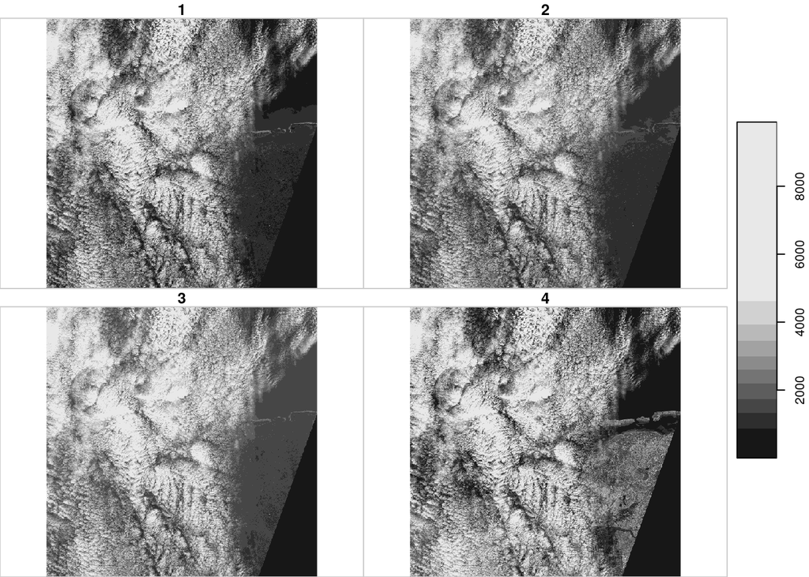

```
##    user  system elapsed
##   0.763   0.176   0.448
```

```r
system.time(plot(p))
```

takes less than a second, because only pixels that can be seen are read; plotting the full 10000 x 10000 images would have taken more than 10 minutes.

We can compute an index like [ndvi](https://en.wikipedia.org/wiki/Normalized_difference_vegetation_index), and plot it:

```r
ndvi = function(x) (x[4] - x[1])/(x[4] + x[1])
rm(x)
(s2.ndvi = st_apply(p, c("x", "y"), ndvi))
```

```
## stars_proxy object with 1 attribute in file:
## $`MTD_MSIL1C.xml:10m:EPSG_32632`
## [1] "SENTINEL2_L1C:/vsizip//home/edzer/R/x86_64-pc-linux-gnu-library/3.6/starsdata/sentinel/S2A_MSIL1C_20180220T105051_N0206_R051_T32ULE_20180221T134037.zip/S2A_MSIL1C_20180220T105051_N0206_R051_T32ULE_20180221T134037.SAFE/MTD_MSIL1C.xml:10m:EPSG_32632"
##
## dimension(s):
##      from    to offset delta                       refsys point values
## x       1 10980  3e+05    10 +proj=utm +zone=32 +datum...    NA   NULL [x]
## y       1 10980  6e+06   -10 +proj=utm +zone=32 +datum...    NA   NULL [y]
## band    1     4     NA    NA                           NA    NA   NULL
## call list:
## [[1]]
## st_apply(X = X, MARGIN = c("x", "y"), FUN = ndvi)
```

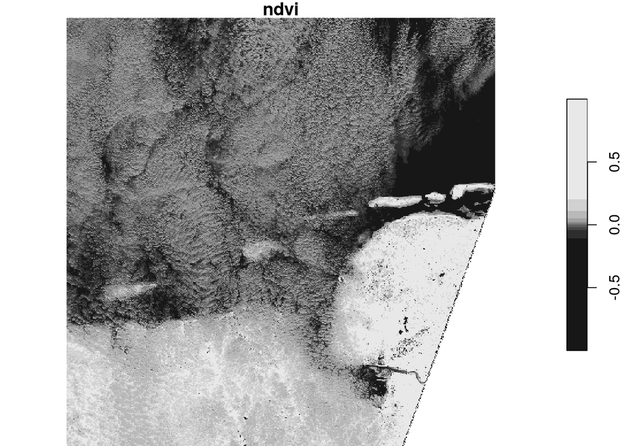

```
##    user  system elapsed
##   0.993   0.120   0.625
```

```r
system.time(plot(s2.ndvi)) # read - compute ndvi - plot
```

where lazy evaluation is used: `s2.ndvi` still contains no pixels, but only `plot` calls for them, and instructs `st_apply` to only work on the resolution called for. If we would save `s2.ndvi` to disk, the full resolution would be computed: the command

```r
write_stars(s2.ndvi, "s2.tif")
```

takes 5 minutes and writes a 500 Mb GeoTIFF.

### Exercises

1. Start R, install package `stars` (if not already present), and load it
2. load the Landsat image test set, as above
3. Create an RGB composite plot using argument `rgb = c(3,2,1)` for RGB, and `rgb = c(4,3,2)` for false color.
4. Use `x6 = split(x, "band")` to create a 2-dimensional raster with 6 attributes
5. Plot `x6`. What has changed?
6. Compute the mean of all six bands by adding all six attributes and dividing by 6, and assigning the resulting matrix as a new attribute in `x6`
7. As an alternative, compute the mean of all six bands by applying function `mean` over the `x` and `y` dimensions (essentially reducing “band”), by using `st_apply`; compare the results of the two approaches

## C. Raster/vector data cubes, large rasters (20’ + 10’ exercises)

This section tries to bring everything together: simple features, vector data, time series, and rasters.

### spatial time series

We will create a stars object from the space/time matrix in `air`:

```r
a = air[,sel]
dim(a)
```

```
## space  time
##    70   501
```

```r
library(units)
(a.st = st_as_stars(list(PM10 = set_units(air[,sel], ppm))))
```

```
## stars object with 2 dimensions and 1 attribute
## attribute(s):
##    PM10 [ppm]
##  Min.   :  1.125
##  1st Qu.: 11.350
##  Median : 17.542
##  Mean   : 21.323
##  3rd Qu.: 26.583
##  Max.   :274.333
##  NA's   :10901
## dimension(s):
##       from  to offset delta refsys point values
## space    1  70     NA    NA     NA    NA   NULL
## time     1 501     NA    NA     NA    NA   NULL
```

however, this has still no knowledge of space and time dimensions, and reference systems. We can add this:

```r
crs = 32632 # UTM zone 32N
a.st %>%
  st_set_dimensions(1, values = st_as_sfc(stations)) %>%
  st_set_dimensions(2, values = dates[sel]) %>%
  st_transform(crs) -> a.st2
a.st2
```

```
## stars object with 2 dimensions and 1 attribute
## attribute(s):
##    PM10 [ppm]
##  Min.   :  1.125
##  1st Qu.: 11.350
##  Median : 17.542
##  Mean   : 21.323
##  3rd Qu.: 26.583
##  Max.   :274.333
##  NA's   :10901
## dimension(s):
##      from  to     offset  delta                       refsys point
## sfc     1  70         NA     NA +proj=utm +zone=32 +datum...  TRUE
## time    1 501 2002-12-05 1 days                         Date    NA
##                                                     values
## sfc  POINT (538708.6 5947030),...,POINT (532512.2 5454307)
## time                                                  NULL
```

```r
st_bbox(a.st2)
```

```
##      xmin      ymin      xmax      ymax
##  307809.3 5295751.9  907374.8 6086661.1
```

```r
st_crs(a.st2)
```

```
## Coordinate Reference System:
##   EPSG: 32632
##   proj4string: "+proj=utm +zone=32 +datum=WGS84 +units=m +no_defs"
```

### geostatistics with sf and stars (10’)

For the following to run well, we need `stars` (>= 0.3-2) installed from github:

```r
remotes::install_github("r-spatial/stars")
```

We can interpolate these spatial time series, when we have a target grid, e.g. created by

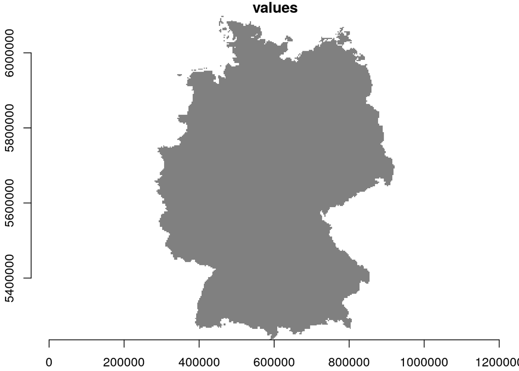

```r
DE_NUTS1 %>% st_as_sfc() %>% st_transform(crs) -> de # DE_NUTS1 is part of the "air" datasets
grd = st_as_stars(de)
grd[[1]][grd[[1]] == 0] = NA
plot(grd, axes = TRUE)
```

We will work with temporal means, rather than full space/time variability, and fit a variogram to the temporal mean PM10 values:

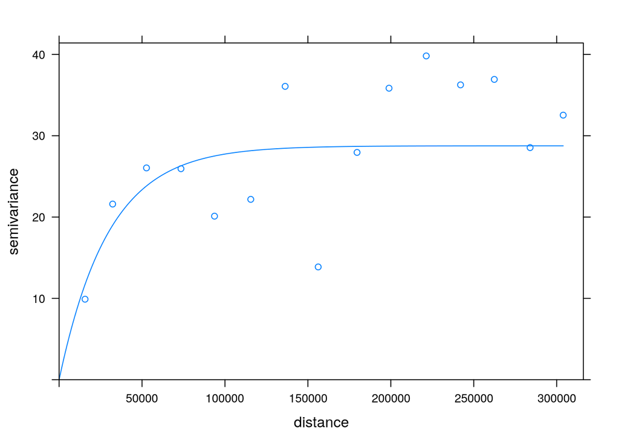

```r
library(gstat)
st_apply(a.st2, "sfc", mean, na.rm = TRUE) %>%
    st_as_sf() %>%
    na.omit()  -> a.means
v = variogram(mean ~ 1, a.means)
v.fit = fit.variogram(v, vgm(10, "Exp", 1e5, 10))
plot(v, v.fit)
```

Then, we can use this for kriging:

```r
int <- krige(mean~1, a.means, grd, v.fit)
```

```
## [using ordinary kriging]
```

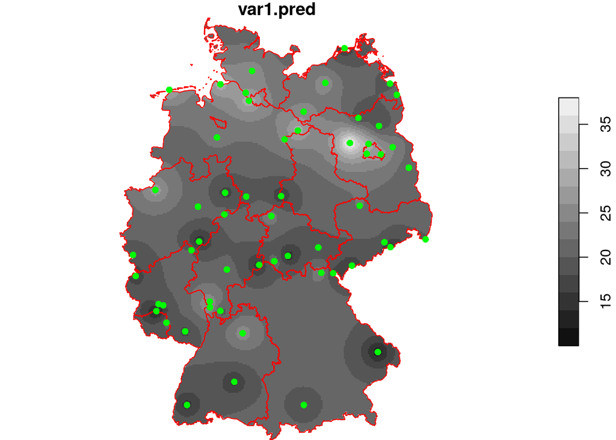

```r
plot(int, reset = FALSE, key.pos = 4, breaks = "pretty")
plot(de, col = NA, border = 'red', add = TRUE)
plot(st_geometry(a.means), col = 'green', add = TRUE, pch = 16)
```

A `ggplot2` plot of the same is obtained by

```r
library(viridis)
```

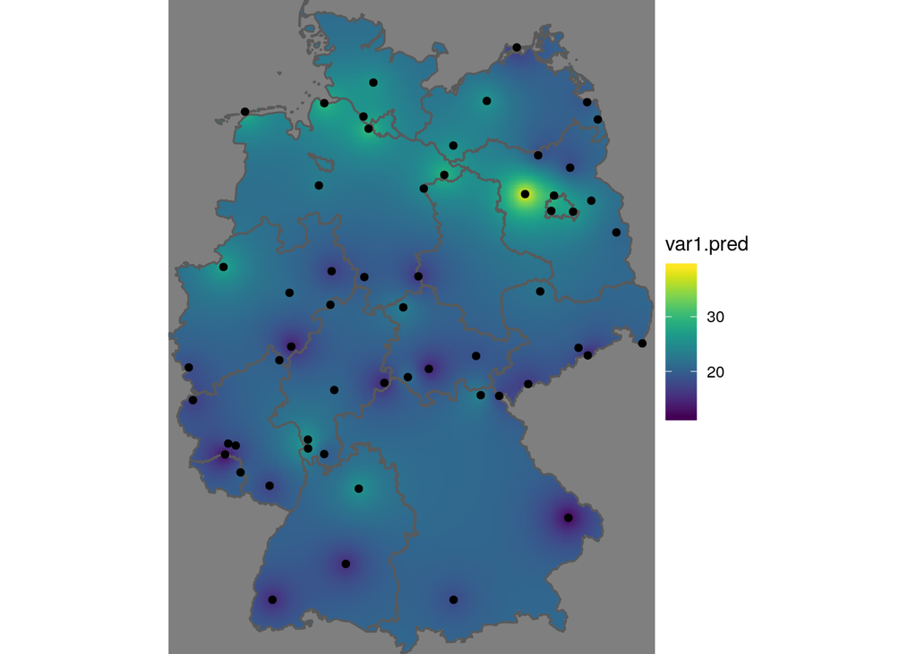

```r
g = ggplot() + coord_equal() +
    scale_fill_viridis() +
    theme_void() +
    scale_x_discrete(expand=c(0,0)) +
    scale_y_discrete(expand=c(0,0))
g + geom_stars(data = int) + geom_sf(data = de, fill = NA) + geom_sf(data = a.means)
```

It is likely that `geom_stars()` will be developed further, to take some of the defaults now being set for creating object `g`.

A further worked out space/time case study on this type of data is found in the geostatistics/interpolation chapter of (Pebesma and Bivand forthcoming ).

### stars: time, raster, data cubes (15’)

`read_ncdf`

### Transforming rasters

Consider the following, curvilinear, grid:

```r
prec_file = system.file("nc/test_stageiv_xyt.nc", package = "stars")
(prec = read_ncdf(prec_file, curvilinear = c("lon", "lat")))
```

```
## stars object with 3 dimensions and 1 attribute
## attribute(s):
##  Total_precipitation_surface_1_Hour_Accumulation
##  Min.   :  0.000
##  1st Qu.:  0.000
##  Median :  0.750
##  Mean   :  4.143
##  3rd Qu.:  4.630
##  Max.   :163.750
## dimension(s):
##      from  to                  offset  delta                       refsys
## x       1  87                      NA     NA +proj=longlat +datum=WGS8...
## y       1 118                      NA     NA +proj=longlat +datum=WGS8...
## time    1  23 2001-12-31 23:00:00 UTC 0 secs                      POSIXct
##      point                         values
## x       NA [87x118] -80.6113,...,-74.8822 [x]
## y       NA   [87x118] 32.4413,...,37.6193 [y]
## time    NA                           NULL
## curvilinear grid
```

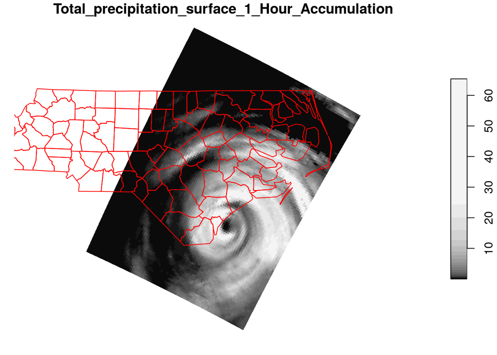

```r
## plot(prec) ## gives error about unique breaks:
## remove NAs, zeros, and give a large number
## of breaks (used for validating in detail)
qu_0_omit = function(x, ..., n = 22) {
  x = na.omit(x)
  c(0, quantile(x[x > 0], seq(0, 1, length.out = n)))
}
library(dplyr) # loads slice generic
prec_slice = slice(prec, index = 17, along = "time")
breaks = qu_0_omit(prec_slice[[1]])
plot(prec_slice, border = NA, breaks = breaks, reset = FALSE)
nc = sf::read_sf(system.file("gpkg/nc.gpkg", package = "sf"), "nc.gpkg")
plot(st_geometry(nc), add = TRUE, reset = FALSE, col = NA, border = 'red')
```

With such a grid, and any other grid, `st_transform` simply creates a new curvilinear grid:

```r
(nc_state_plane = st_crs(2264))
```

```
## Coordinate Reference System:
##   EPSG: 2264
##   proj4string: "+proj=lcc +lat_1=36.16666666666666 +lat_2=34.33333333333334 +lat_0=33.75 +lon_0=-79 +x_0=609601.2192024384 +y_0=0 +ellps=GRS80 +towgs84=0,0,0,0,0,0,0 +units=us-ft +no_defs"
```

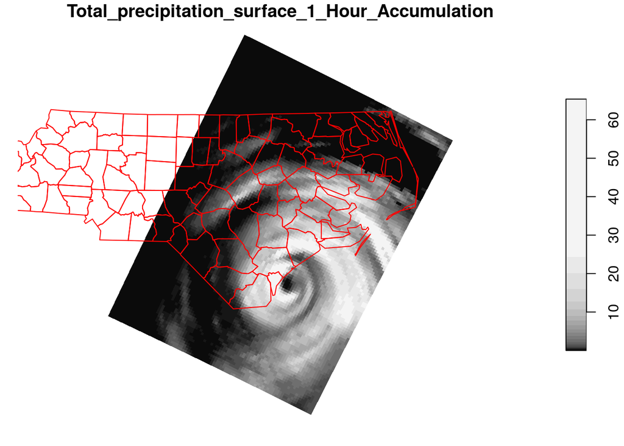

```r
prec_slice %>%
  st_transform(nc_state_plane) %>%
  plot(border = NA, breaks = breaks, reset = FALSE)
nc %>%
  st_transform(nc_state_plane) %>%
  plot(add = TRUE, reset = FALSE, col = NA, border = 'red')
```

We can *warp* a **regular** grid to be a new **regular** grid in the existing, or to a default grid in a new target CRS, e.g. by

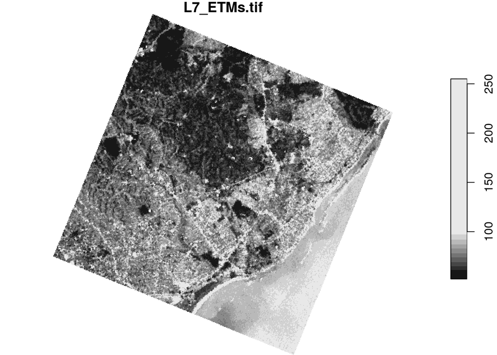

```r
tif = system.file("tif/L7_ETMs.tif", package = "stars")
read_stars(tif) %>%
  slice(prec, index = 1, along = "band") %>%
  st_warp(crs = "+proj=lcc") %>%
  plot()
```

As an option, it can use `gdalwarp`, using its library interface (see `sf::gdal_utils`).

## References

Herring, John R. 2011. “OpenGIS Implementation Standard for Geographic Information-Simple Feature Access-Part 1: Common Architecture.” *Open Geospatial Consortium Inc*, 111. http://portal.opengeospatial.org/files/?artifact_id=25355.

Pebesma, Edzer, and Roger S. Bivand. forthcoming. *Spatial Data Science; Uses Cases in R*. CRC. https://r-spatial.org/book/.